# pure_mt406390_xai3

## Data Overview

### Features

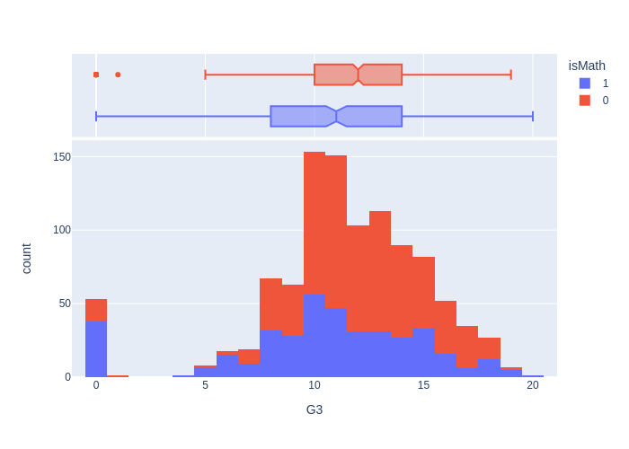

Firstly we made plots of the distributions over our target variable. We see that we have kind of class imbalance in this dataset since there is lack of 1-4 and 19+ classes. Also number of 5,6,7 is very small. This can indicate future problems with classification. For now, we don't transform our target variable, however in future it would be needed to dig deeper into drivers of grades so that better feature engineering might be constructed.

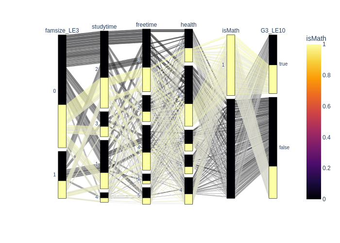

Here we see interesting plot of parallel categories. Firstly we split our target variable into 2 sets, those with values less/equal than 10 and those with higher. From that perspective we could conclude that there is imbalance of G3 across classes.

# Homework 3

For the selected dataset and models, prepare a knitr/jupyter notebook based on the following points (you can reuse models from previous Homeworks). Submit your results on GitHub to the directory Homeworks/HW3.

1. Calculate the predictions for some selected observations
2. Then, calculate the decomposition of these predictions with LIME using the package of choice, e.g. in Python: lime, dalex, in R: iml, localModel.
3. Compare LIME for various observations in the dataset. How stable are these explanations?
4. Compare LIME with the explanations obtained using SHAP. What are the main differences between them?
5. Compare LIME between at least two different models. Are there any systematic differences across many observations?

Comment on the results obtained in (3), (4) and (5)

Training already done in previous homework

## Calculate the predictions for some selected observations

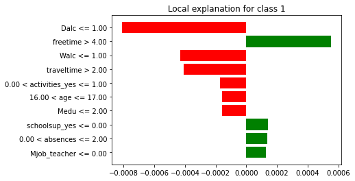

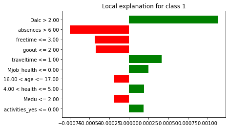

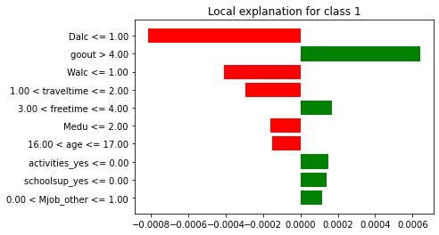

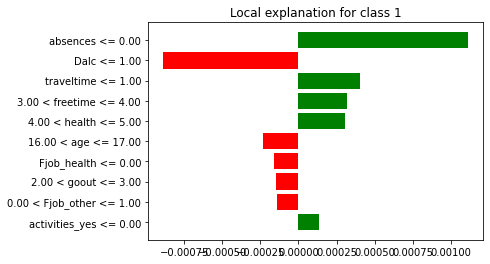

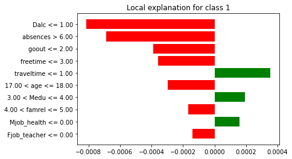

## How stable are these explanations?

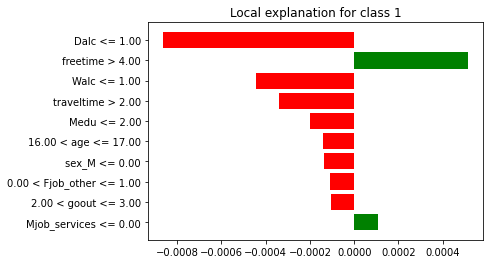

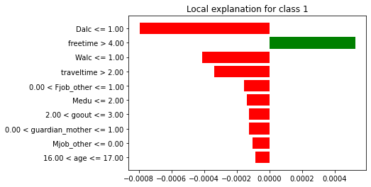

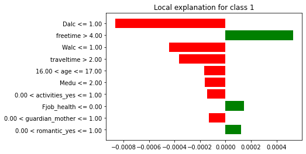

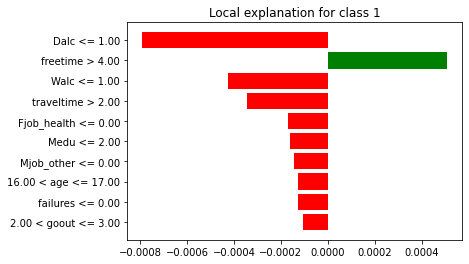

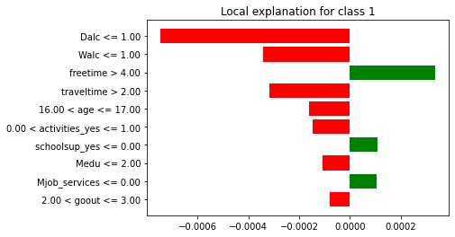

They are quite stable, however sometimes results swap a little to other sign or change the order of importane. I guess that this is caused because of small numbers and enough variance to swap this. Nonetheless this algorithm seems to be stable across many runs.

## Compare LIME with the explanations obtained using SHAP. What are the main differences between them?

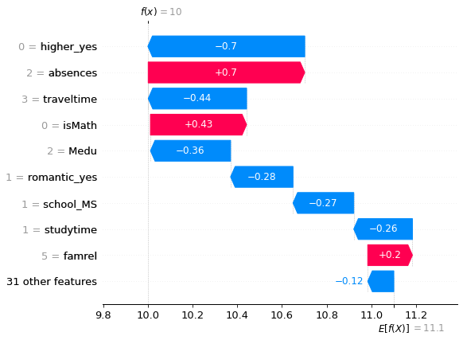

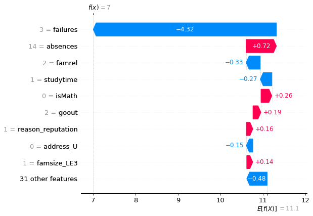

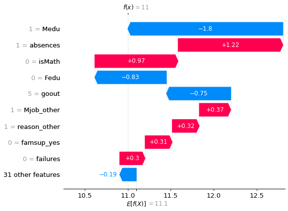

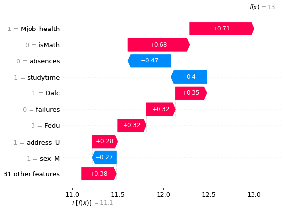

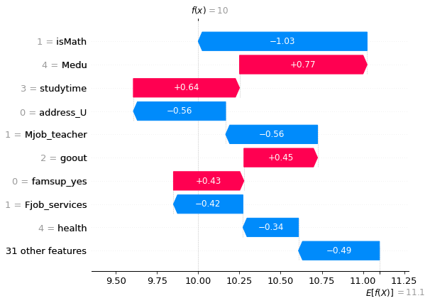

Differences between two models are signifficant. In most examples both order and signifficancy of the model differs across them. It might be because our training dataset is very small so that it is very hard to tune accurate model in so sparse space. https://en.wikipedia.org/wiki/Curse_of_dimensionality

## Compare LIME between at least two different models. Are there any systematic differences across many observations?

### First Model

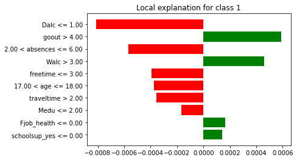

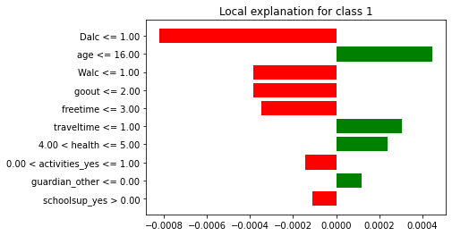

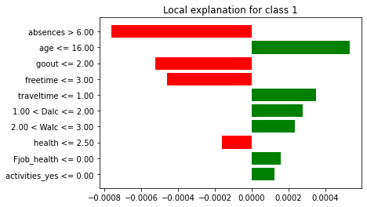

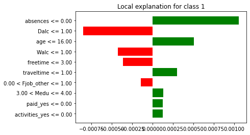